# DEFENSIVE TRAITS C.arvensis SIBECOL 2025

Andrés Delgado Galán

2025-05-18

### C.arvensis - PRODUCCIÓN DE FLORES

**sqrt(flor) ~ trat + clip + trat:clip**  
n = **36**

R² = **-0.0406508**

##### CAflor Post-hoc Comparisons with Tukeys HSD

| contrast | trat | estimate | SE | df | t.ratio | p.value |
| --- | --- | --- | --- | --- | --- | --- |
| no - yes | ex | 0.5692288 | 0.5495189 | 32 | 1.0358675 | 0.3080288 |
| no - yes | gra | -0.2278591 | 0.8312098 | 32 | -0.2741295 | 0.7857470 |

| contrast | clip | estimate | SE | df | t.ratio | p.value |
| --- | --- | --- | --- | --- | --- | --- |
| ex - gra | no | 0.0310498 | 0.6774924 | 32 | 0.0458305 | 0.9637302 |
| ex - gra | yes | -0.7660381 | 0.7306742 | 32 | -1.0483990 | 0.3023090 |

ANOVA Results for CAflor Model

| Response | Predictor | Sum Sq | Df | F value | Pr(>F) |
| --- | --- | --- | --- | --- | --- |
| CA flor | trat | 0.869 | 1 | 0.461 | 0.502 |
| CA flor | clip | 0.958 | 1 | 0.508 | 0.481 |
| CA flor | trat:clip | 1.206 | 1 | 0.640 | 0.430 |
| CA flor | Residuals | 60.298 | 32 | NA | NA |

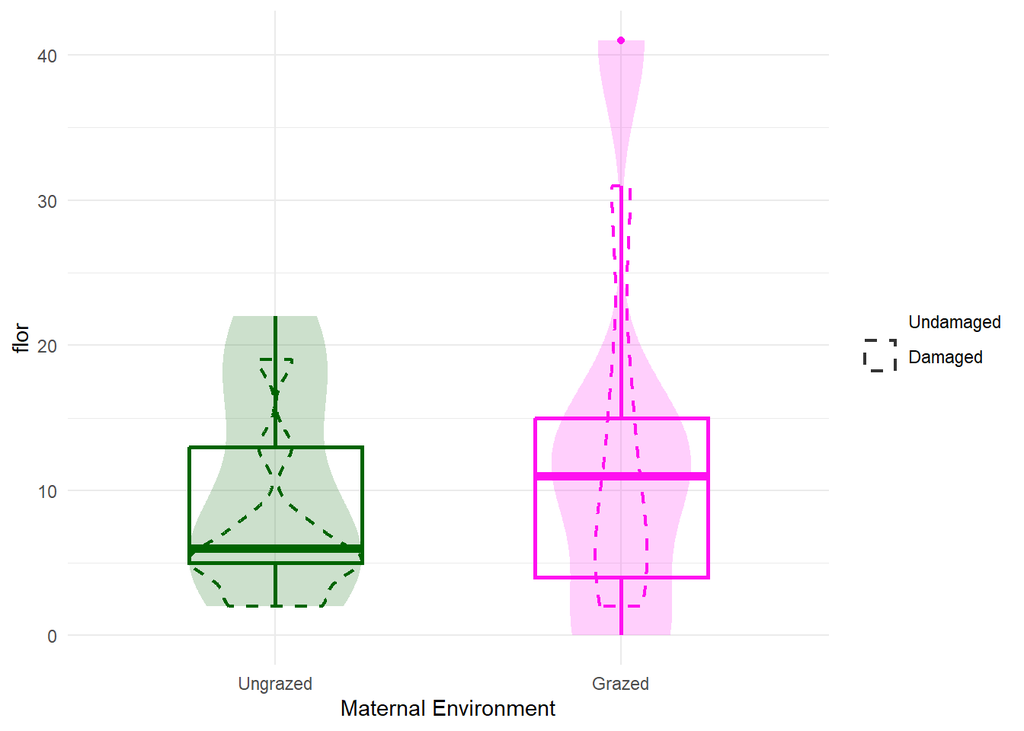

### C.arvensis - PRODUCCIÓN DE FRUTOS

**sqrt(fruto) ~ trat + clip + trat:clip**  
n = **36**

R² = **-0.0256685**

##### CAfruto Post-hoc Comparisons with Tukeys HSD

| contrast | trat | estimate | SE | df | t.ratio | p.value |
| --- | --- | --- | --- | --- | --- | --- |
| no - yes | ex | 0.6708459 | 0.5389725 | 32 | 1.2446756 | 0.2222900 |
| no - yes | gra | -0.1568861 | 0.8152572 | 32 | -0.1924376 | 0.8486155 |

| contrast | clip | estimate | SE | df | t.ratio | p.value |
| --- | --- | --- | --- | --- | --- | --- |
| ex - gra | no | 0.0360704 | 0.6644899 | 32 | 0.0542829 | 0.9570473 |
| ex - gra | yes | -0.7916617 | 0.7166510 | 32 | -1.1046683 | 0.2775405 |

ANOVA Results for CAfruto Model

| Response | Predictor | Sum Sq | Df | F value | Pr(>F) |
| --- | --- | --- | --- | --- | --- |
| CA fruto | trat | 0.917 | 1 | 0.506 | 0.482 |
| CA fruto | clip | 1.575 | 1 | 0.869 | 0.358 |
| CA fruto | trat:clip | 1.300 | 1 | 0.717 | 0.403 |
| CA fruto | Residuals | 58.005 | 32 | NA | NA |

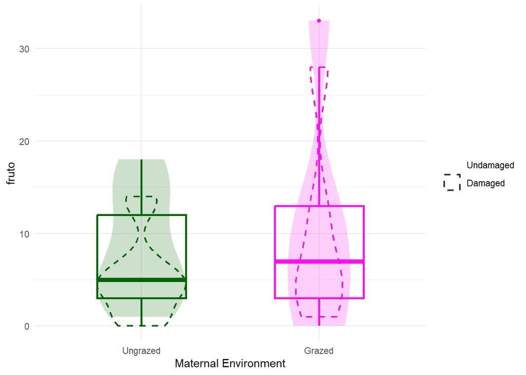

### C.arvensis - PRODUCCIÓN DE HOJAS

**log(hojas) ~ trat + clip + trat:clip**  
n = **36**

R² = **-0.0098119**

##### CAhojas Post-hoc Comparisons with Tukeys HSD

| contrast | trat | estimate | SE | df | t.ratio | p.value |
| --- | --- | --- | --- | --- | --- | --- |
| no - yes | ex | 0.2105144 | 0.1877384 | 32 | 1.1213178 | 0.2704970 |
| no - yes | gra | -0.1863148 | 0.2839756 | 32 | -0.6560942 | 0.5164537 |

| contrast | clip | estimate | SE | df | t.ratio | p.value |
| --- | --- | --- | --- | --- | --- | --- |
| ex - gra | no | 0.0184386 | 0.2314594 | 32 | 0.0796625 | 0.9370018 |
| ex - gra | yes | -0.3783905 | 0.2496285 | 32 | -1.5158145 | 0.1393833 |

ANOVA Results for CAhojas Model

| Response | Predictor | Sum Sq | Df | F value | Pr(>F) |
| --- | --- | --- | --- | --- | --- |
| CA hojas | trat | 0.208 | 1 | 0.945 | 0.338 |
| CA hojas | clip | 0.072 | 1 | 0.329 | 0.570 |
| CA hojas | trat:clip | 0.299 | 1 | 1.359 | 0.252 |
| CA hojas | Residuals | 7.038 | 32 | NA | NA |

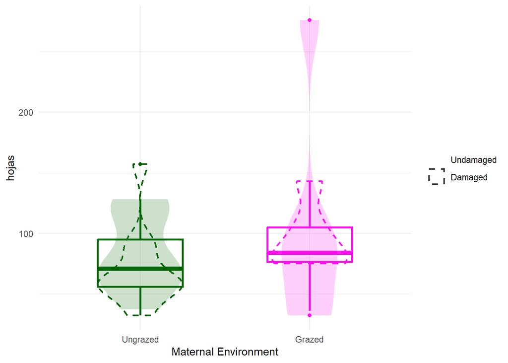

### C.arvensis - ALTURA MÁXIMA

**sqrt(altura) ~ trat + clip + trat:clip**  
n = **37**

R² = **-0.0151995**

##### CAaltura Post-hoc Comparisons with Tukeys HSD

| contrast | trat | estimate | SE | df | t.ratio | p.value |
| --- | --- | --- | --- | --- | --- | --- |
| no - yes | ex | 0.6974507 | 0.4493633 | 33 | 1.552086 | 0.1301804 |
| no - yes | gra | -0.0912982 | 0.6937293 | 33 | -0.131605 | 0.8960959 |

| contrast | clip | estimate | SE | df | t.ratio | p.value |
| --- | --- | --- | --- | --- | --- | --- |
| ex - gra | no | 0.4670044 | 0.5654365 | 33 | 0.8259184 | 0.4147818 |
| ex - gra | yes | -0.3217445 | 0.6028842 | 33 | -0.5336754 | 0.5971428 |

ANOVA Results for CAaltura Model

| Response | Predictor | Sum Sq | Df | F value | Pr(>F) |
| --- | --- | --- | --- | --- | --- |
| CA altura | trat | 0.074 | 1 | 0.056 | 0.814 |
| CA altura | clip | 1.989 | 1 | 1.516 | 0.227 |
| CA altura | trat:clip | 1.195 | 1 | 0.911 | 0.347 |
| CA altura | Residuals | 43.313 | 33 | NA | NA |

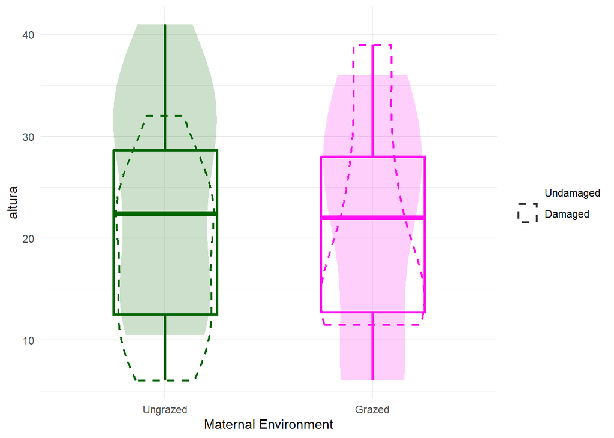

### C.arvensis - SEMILLAS/FRUTO

**sqrt(seedfruto) ~ trat + clip + trat:clip**  
n = **30**

R² = **-0.1003155**

##### CAseedfruto Post-hoc Comparisons with Tukeys HSD

| contrast | trat | estimate | SE | df | t.ratio | p.value |
| --- | --- | --- | --- | --- | --- | --- |
| no - yes | ex | 0.0536900 | 0.1317905 | 26 | 0.4073890 | 0.6870572 |
| no - yes | gra | 0.0875563 | 0.2023378 | 26 | 0.4327233 | 0.6687841 |

| contrast | clip | estimate | SE | df | t.ratio | p.value |
| --- | --- | --- | --- | --- | --- | --- |
| ex - gra | no | -0.0166460 | 0.1761124 | 26 | -0.0945194 | 0.9254212 |
| ex - gra | yes | 0.0172202 | 0.1652081 | 26 | 0.1042336 | 0.9177839 |

ANOVA Results for CAseedfruto Model

| Response | Predictor | Sum Sq | Df | F value | Pr(>F) |
| --- | --- | --- | --- | --- | --- |
| CA seedfruto | trat | 0.000 | 1 | 0.000 | 0.991 |
| CA seedfruto | clip | 0.030 | 1 | 0.334 | 0.569 |
| CA seedfruto | trat:clip | 0.002 | 1 | 0.020 | 0.890 |
| CA seedfruto | Residuals | 2.365 | 26 | NA | NA |

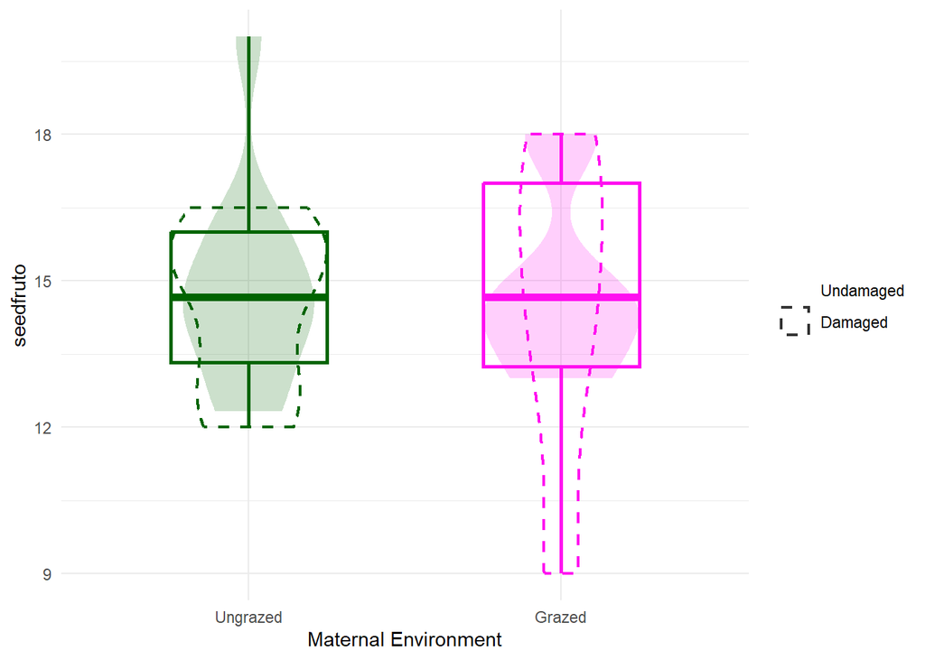

### C.arvensis - PRODUCCIÓN DE SEMILLAS

**sqrt(seedtotal) ~ trat + clip + trat:clip**  
n = **37**

R² = **-0.0266484**

##### CAseedtotal Post-hoc Comparisons with Tukeys HSD

| contrast | trat | estimate | SE | df | t.ratio | p.value |
| --- | --- | --- | --- | --- | --- | --- |
| no - yes | ex | 2.484847 | 1.953746 | 33 | 1.2718377 | 0.2123211 |
| no - yes | gra | -1.589080 | 3.016202 | 33 | -0.5268479 | 0.6018231 |

| contrast | clip | estimate | SE | df | t.ratio | p.value |
| --- | --- | --- | --- | --- | --- | --- |
| ex - gra | no | 1.225125 | 2.458409 | 33 | 0.4983407 | 0.6215493 |
| ex - gra | yes | -2.848802 | 2.621225 | 33 | -1.0868209 | 0.2849909 |

ANOVA Results for CAseedtotal Model

| Response | Predictor | Sum Sq | Df | F value | Pr(>F) |
| --- | --- | --- | --- | --- | --- |
| CA seedtotal | trat | 3.583 | 1 | 0.144 | 0.706 |
| CA seedtotal | clip | 15.135 | 1 | 0.610 | 0.440 |
| CA seedtotal | trat:clip | 31.886 | 1 | 1.285 | 0.265 |
| CA seedtotal | Residuals | 818.773 | 33 | NA | NA |

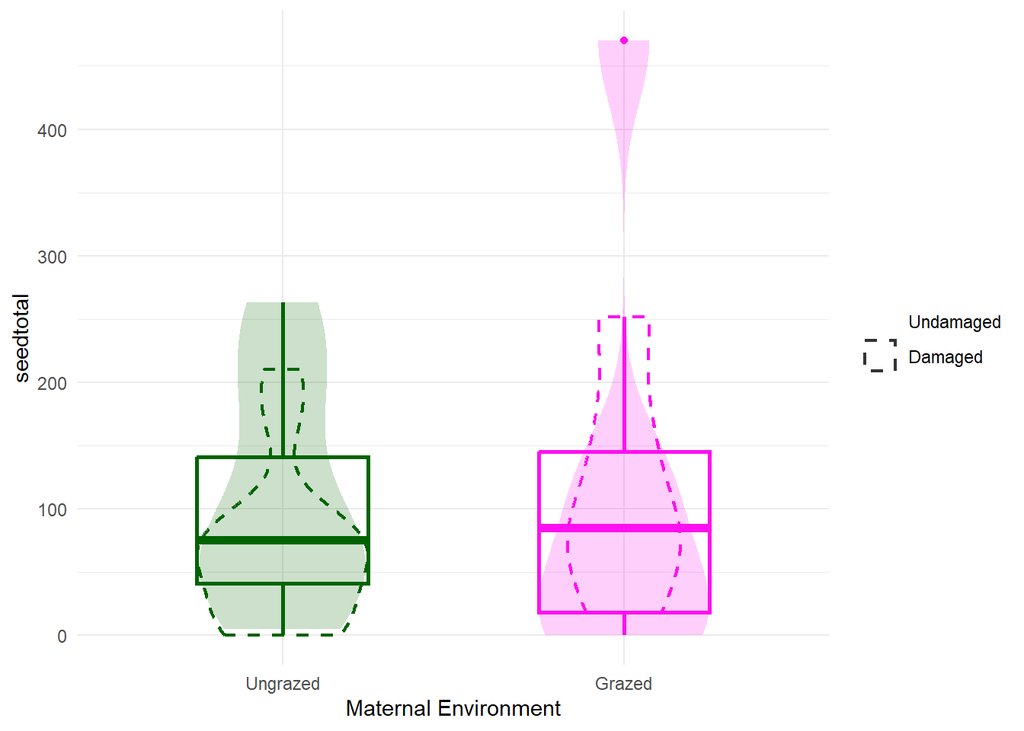

### C.arvensis - PESO MEDIO DE LAS SEMILLAS

**sqrt(massseed) ~ trat + clip + trat:clip**  
n = **36**

R² = **-0.0104719**

##### CAmassseed Post-hoc Comparisons with Tukeys HSD

| contrast | trat | estimate | SE | df | t.ratio | p.value |
| --- | --- | --- | --- | --- | --- | --- |
| no - yes | ex | 0.0089945 | 0.0057445 | 32 | 1.5657487 | 0.1272442 |
| no - yes | gra | -0.0036509 | 0.0092628 | 32 | -0.3941521 | 0.6960832 |

| contrast | clip | estimate | SE | df | t.ratio | p.value |
| --- | --- | --- | --- | --- | --- | --- |
| ex - gra | no | 0.0072722 | 0.0077071 | 32 | 0.9435789 | 0.3524549 |
| ex - gra | yes | -0.0053732 | 0.0077071 | 32 | -0.6971732 | 0.4907288 |

ANOVA Results for CAmassseed Model

| Response | Predictor | Sum Sq | Df | F value | Pr(>F) |
| --- | --- | --- | --- | --- | --- |
| CA massseed | trat | 0.000 | 1 | 0.030 | 0.863 |
| CA massseed | clip | 0.000 | 1 | 1.261 | 0.270 |
| CA massseed | trat:clip | 0.000 | 1 | 1.346 | 0.255 |
| CA massseed | Residuals | 0.007 | 32 | NA | NA |

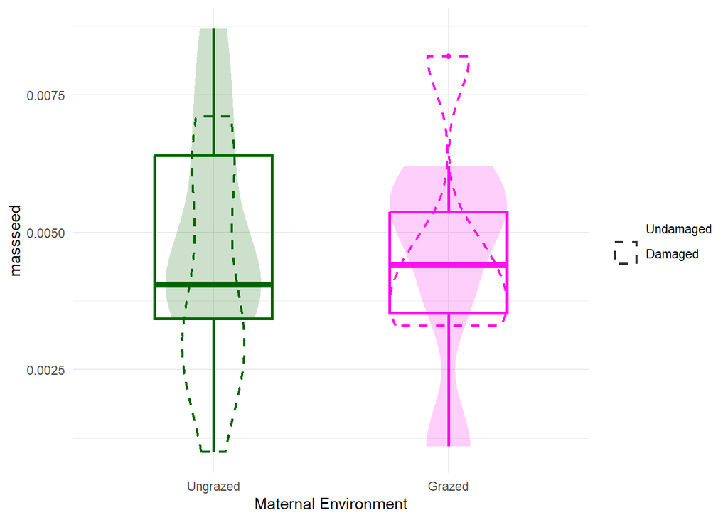

### C.arvensis - SLA

**sqrt(SLA) ~ trat + clip + trat:clip**  
n = **33**

R² = **0.0257301**

##### CASLA Post-hoc Comparisons with Tukeys HSD

| contrast | trat | estimate | SE | df | t.ratio | p.value |
| --- | --- | --- | --- | --- | --- | --- |
| no - yes | ex | -1.525396 | 1.196162 | 29 | -1.275242 | 0.2123456 |
| no - yes | gra | -3.031048 | 2.112844 | 29 | -1.434582 | 0.1621031 |

| contrast | clip | estimate | SE | df | t.ratio | p.value |
| --- | --- | --- | --- | --- | --- | --- |
| ex - gra | no | 1.2701025 | 1.708462 | 29 | 0.7434189 | 0.4632089 |
| ex - gra | yes | -0.2355492 | 1.725130 | 29 | -0.1365400 | 0.8923379 |

ANOVA Results for CASLA Model

| Response | Predictor | Sum Sq | Df | F value | Pr(>F) |
| --- | --- | --- | --- | --- | --- |
| CA SLA | trat | 1.667 | 1 | 0.187 | 0.669 |
| CA SLA | clip · | 29.460 | 1 | 3.300 | 0.080 |
| CA SLA | trat:clip | 3.433 | 1 | 0.385 | 0.540 |
| CA SLA | Residuals | 258.918 | 29 | NA | NA |

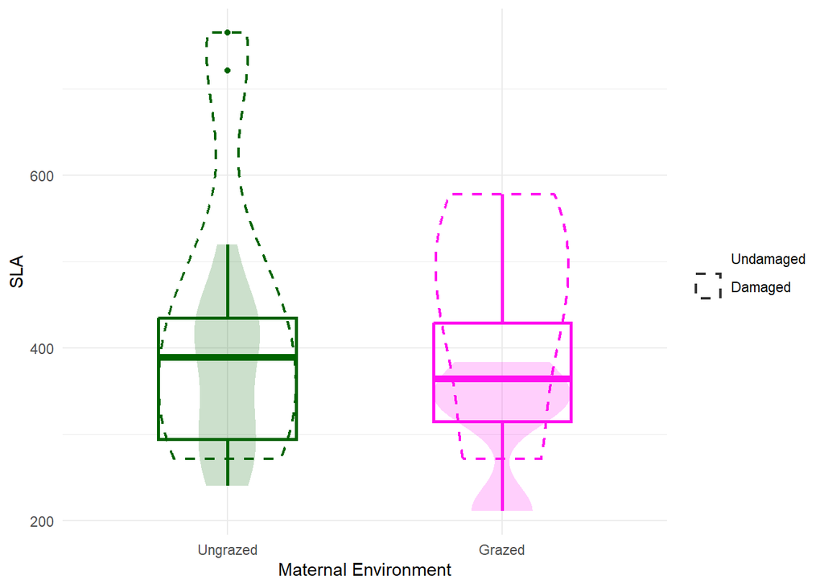

### C.arvensis - LDMC

**sqrt(LDMC) ~ trat + clip + trat:clip**  
n = **31**

R² = **-5.7862873^{-6}**

##### CALDMC Post-hoc Comparisons with Tukeys HSD

| contrast | trat | estimate | SE | df | t.ratio | p.value |
| --- | --- | --- | --- | --- | --- | --- |
| no - yes | ex | 0.0228262 | 0.0149454 | 27 | 1.5273067 | 0.1383159 |
| no - yes | gra | 0.0221351 | 0.0278630 | 27 | 0.7944264 | 0.4338749 |

| contrast | clip | estimate | SE | df | t.ratio | p.value |
| --- | --- | --- | --- | --- | --- | --- |
| ex - gra | no | -0.0051619 | 0.0233667 | 27 | -0.2209104 | 0.8268242 |
| ex - gra | yes | -0.0058530 | 0.0213004 | 27 | -0.2747843 | 0.7855737 |

ANOVA Results for CALDMC Model

| Response | Predictor | Sum Sq | Df | F value | Pr(>F) |
| --- | --- | --- | --- | --- | --- |
| CA LDMC | trat | 0.000 | 1 | 0.124 | 0.728 |
| CA LDMC | clip · | 0.004 | 1 | 2.963 | 0.097 |
| CA LDMC | trat:clip | 0.000 | 1 | 0.000 | 0.983 |
| CA LDMC | Residuals | 0.036 | 27 | NA | NA |

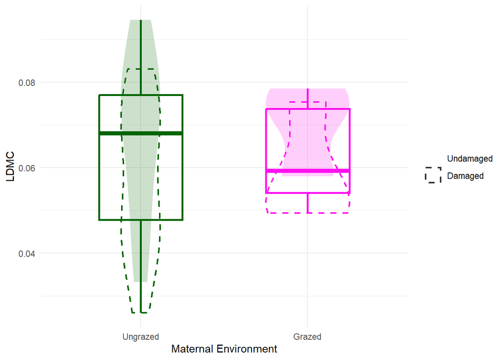

### C.arvensis - ÁREA FOLIAR

**sqrt(area.m) ~ trat + clip + trat:clip**  
n = **33**

R² = **0.2451988**

##### CAarea.m Post-hoc Comparisons with Tukeys HSD

| contrast | trat | estimate | SE | df | t.ratio | p.value |
| --- | --- | --- | --- | --- | --- | --- |
| no - yes | ex | 0.6103344 | 0.1886989 | 29 | 3.234435 | 0.0030385 |
| no - yes | gra | 0.5119383 | 0.3333088 | 29 | 1.535928 | 0.1353958 |

| contrast | clip | estimate | SE | df | t.ratio | p.value |
| --- | --- | --- | --- | --- | --- | --- |
| ex - gra | no | 0.1821348 | 0.2695160 | 29 | 0.6757847 | 0.5045311 |
| ex - gra | yes | 0.0837386 | 0.2721455 | 29 | 0.3076981 | 0.7605112 |

ANOVA Results for CAarea.m Model

| Response | Predictor | Sum Sq | Df | F value | Pr(>F) |
| --- | --- | --- | --- | --- | --- |
| CA area.m | trat | 0.108 | 1 | 0.485 | 0.492 |
| CA area.m | clip ** | 2.834 | 1 | 12.755 | 0.001 |
| CA area.m | trat:clip | 0.015 | 1 | 0.066 | 0.799 |
| CA area.m | Residuals | 6.443 | 29 | NA | NA |

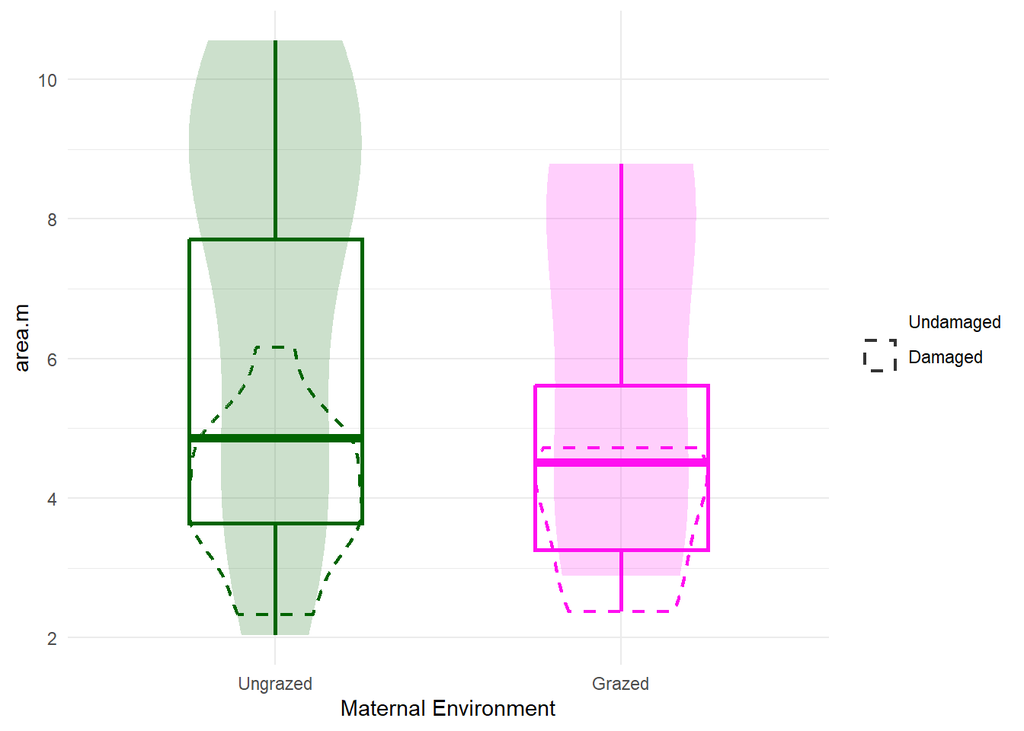

### C.arvensis - FENOLOGÍA DE FLORACIÓN

**sqrt(dias_flor) ~ trat + clip + trat:clip**  
n = **33**

R² = **-0.0715333**

##### CAdias_flor Post-hoc Comparisons with Tukeys HSD

| contrast | trat | estimate | SE | df | t.ratio | p.value |
| --- | --- | --- | --- | --- | --- | --- |
| no - yes | ex | -0.2624514 | 0.5671505 | 29 | -0.4627544 | 0.6469941 |
| no - yes | gra | 0.3957692 | 1.0346417 | 29 | 0.3825181 | 0.7048663 |

| contrast | clip | estimate | SE | df | t.ratio | p.value |
| --- | --- | --- | --- | --- | --- | --- |
| ex - gra | no | 0.0244322 | 0.9145027 | 29 | 0.0267164 | 0.9788689 |
| ex - gra | yes | 0.6826528 | 0.7455387 | 29 | 0.9156505 | 0.3674019 |

ANOVA Results for CAdias_flor Model

| Response | Predictor | Sum Sq | Df | F value | Pr(>F) |
| --- | --- | --- | --- | --- | --- |
| CA dias_flor | trat | 1.060 | 1 | 0.528 | 0.473 |
| CA dias_flor | clip | 0.099 | 1 | 0.049 | 0.826 |
| CA dias_flor | trat:clip | 0.625 | 1 | 0.311 | 0.581 |
| CA dias_flor | Residuals | 58.208 | 29 | NA | NA |

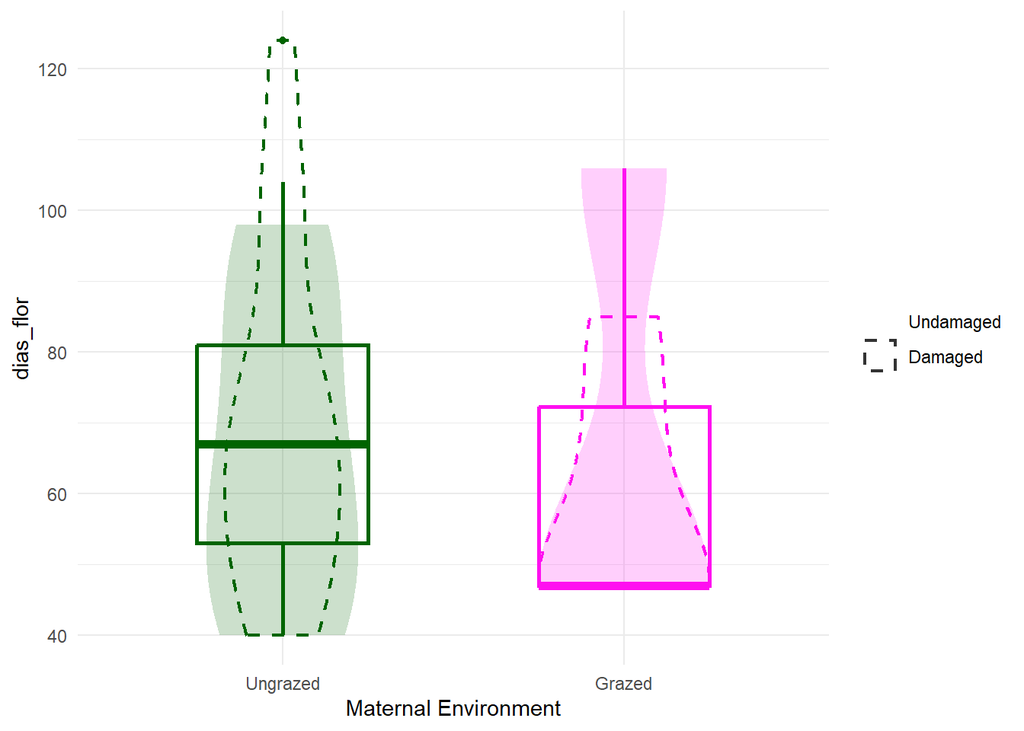

### C.arvensis - FENOLOGÍA DE FRUCTIFICACÓN

**sqrt(dias_fruto) ~ trat + clip + trat:clip**  
n = **34**

R² = **-0.0289342**

##### CAdias_fruto Post-hoc Comparisons with Tukeys HSD

| contrast | trat | estimate | SE | df | t.ratio | p.value |
| --- | --- | --- | --- | --- | --- | --- |
| no - yes | ex | -0.4266130 | 0.606351 | 30 | -0.7035744 | 0.4871230 |
| no - yes | gra | 0.7460602 | 1.016068 | 30 | 0.7342623 | 0.4684894 |

| contrast | clip | estimate | SE | df | t.ratio | p.value |
| --- | --- | --- | --- | --- | --- | --- |
| ex - gra | no | -0.0364776 | 0.8744918 | 30 | -0.0417129 | 0.9670040 |
| ex - gra | yes | 1.1361957 | 0.7970690 | 30 | 1.4254670 | 0.1643446 |

ANOVA Results for CAdias_fruto Model

| Response | Predictor | Sum Sq | Df | F value | Pr(>F) |
| --- | --- | --- | --- | --- | --- |
| CA dias_fruto | trat | 2.412 | 1 | 1.051 | 0.313 |
| CA dias_fruto | clip | 0.119 | 1 | 0.052 | 0.821 |
| CA dias_fruto | trat:clip | 2.253 | 1 | 0.982 | 0.330 |
| CA dias_fruto | Residuals | 68.826 | 30 | NA | NA |

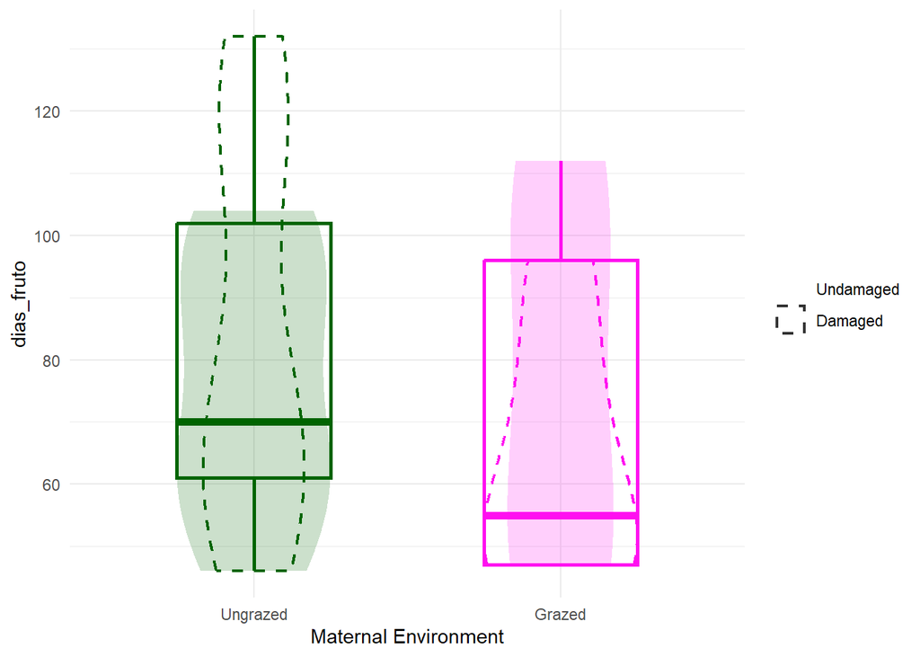

### C.arvensis - PERIODO DE FLORACIÓN

**sqrt(periodo_flor) ~ trat + clip + trat:clip**  
n = **30**

R² = **-0.08722**

##### CAperiodo_flor Post-hoc Comparisons with Tukeys HSD

| contrast | trat | estimate | SE | df | t.ratio | p.value |
| --- | --- | --- | --- | --- | --- | --- |
| no - yes | ex | 0.5221297 | 0.8807099 | 26 | 0.5928509 | 0.5584028 |
| no - yes | gra | -0.7630646 | 1.6114407 | 26 | -0.4735294 | 0.6397875 |

| contrast | clip | estimate | SE | df | t.ratio | p.value |
| --- | --- | --- | --- | --- | --- | --- |
| ex - gra | no | 0.9706199 | 1.361916 | 26 | 0.7126870 | 0.4823870 |
| ex - gra | yes | -0.3145744 | 1.231899 | 26 | -0.2553572 | 0.8004565 |

ANOVA Results for CAperiodo_flor Model

| Response | Predictor | Sum Sq | Df | F value | Pr(>F) |
| --- | --- | --- | --- | --- | --- |
| CA periodo_flor | trat | 0.371 | 1 | 0.083 | 0.775 |
| CA periodo_flor | clip | 0.382 | 1 | 0.086 | 0.772 |
| CA periodo_flor | trat:clip | 2.180 | 1 | 0.490 | 0.490 |
| CA periodo_flor | Residuals | 115.740 | 26 | NA | NA |

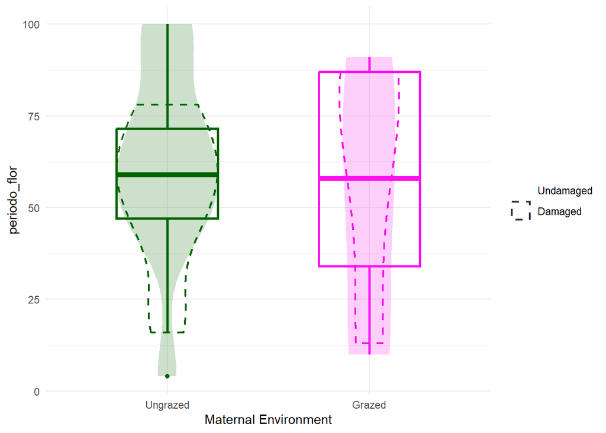

### C.arvensis - PERIODO DE FRUCTIFICACIÓN

**sqrt(periodo_fruto) ~ trat + clip + trat:clip**

n = **33**

R² = **0.0014593**

##### CAperiodo_fruto Post-hoc Comparisons with Tukeys HSD

| contrast | trat | estimate | SE | df | t.ratio | p.value |
| --- | --- | --- | --- | --- | --- | --- |
| no - yes | ex | 1.017987 | 0.8212791 | 29 | 1.239514 | 0.2250925 |
| no - yes | gra | -1.633456 | 1.4506682 | 29 | -1.126002 | 0.2693968 |

| contrast | clip | estimate | SE | df | t.ratio | p.value |
| --- | --- | --- | --- | --- | --- | --- |
| ex - gra | no | 0.9357161 | 1.184466 | 29 | 0.7899901 | 0.4359460 |
| ex - gra | yes | -1.7157268 | 1.173021 | 29 | -1.4626562 | 0.1543156 |

ANOVA Results for CAperiodo_fruto Model

| Response | Predictor | Sum Sq | Df | F value | Pr(>F) |
| --- | --- | --- | --- | --- | --- |
| CA periodo_fruto | trat | 0.983 | 1 | 0.234 | 0.632 |
| CA periodo_fruto | clip | 1.155 | 1 | 0.274 | 0.604 |
| CA periodo_fruto | trat:clip | 10.648 | 1 | 2.530 | 0.123 |
| CA periodo_fruto | Residuals | 122.057 | 29 | NA | NA |

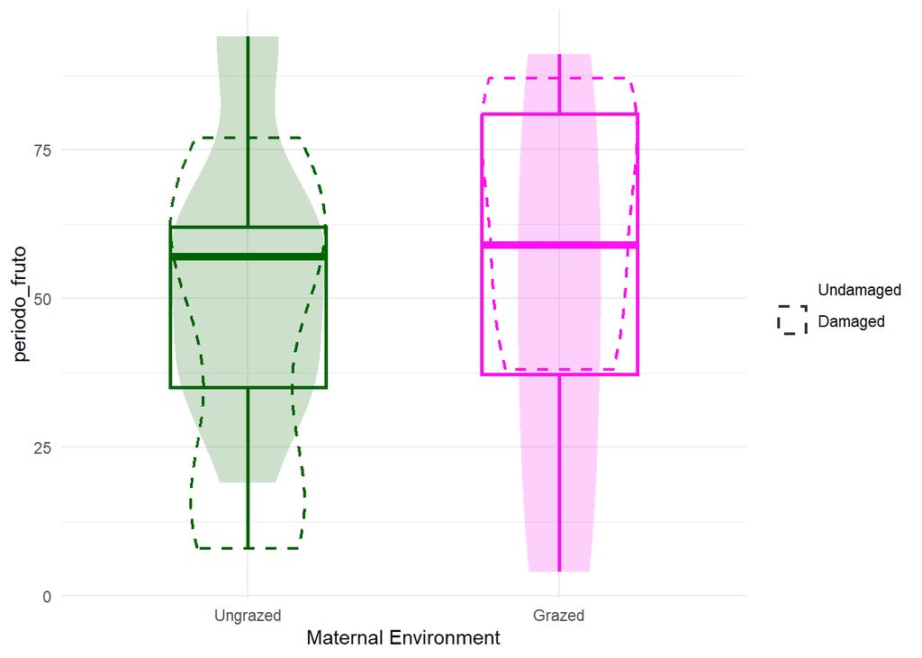

### C.arvensis - ESPERANZA DE VIDA

**sqrt(dias_muerte) ~ trat + clip + trat:clip**  
n = **37**

R² = **0.0329888**

##### CAdias_muerte Post-hoc Comparisons with Tukeys HSD

| contrast | trat | estimate | SE | df | t.ratio | p.value |
| --- | --- | --- | --- | --- | --- | --- |
| no - yes | ex | 0.3816119 | 0.2443401 | 33 | 1.5618062 | 0.1278738 |
| no - yes | gra | -0.2337040 | 0.3772134 | 33 | -0.6195537 | 0.5398061 |

| contrast | clip | estimate | SE | df | t.ratio | p.value |
| --- | --- | --- | --- | --- | --- | --- |
| ex - gra | no | 0.5626249 | 0.3074545 | 33 | 1.829945 | 0.0763043 |
| ex - gra | yes | -0.0526909 | 0.3278166 | 33 | -0.160733 | 0.8732837 |

ANOVA Results for CAdias_muerte Model

| Response | Predictor | Sum Sq | Df | F value | Pr(>F) |
| --- | --- | --- | --- | --- | --- |
| CA dias_muerte | trat | 0.582 | 1 | 1.500 | 0.229 |
| CA dias_muerte | clip | 0.368 | 1 | 0.949 | 0.337 |
| CA dias_muerte | trat:clip | 0.727 | 1 | 1.874 | 0.180 |
| CA dias_muerte | Residuals | 12.806 | 33 | NA | NA |

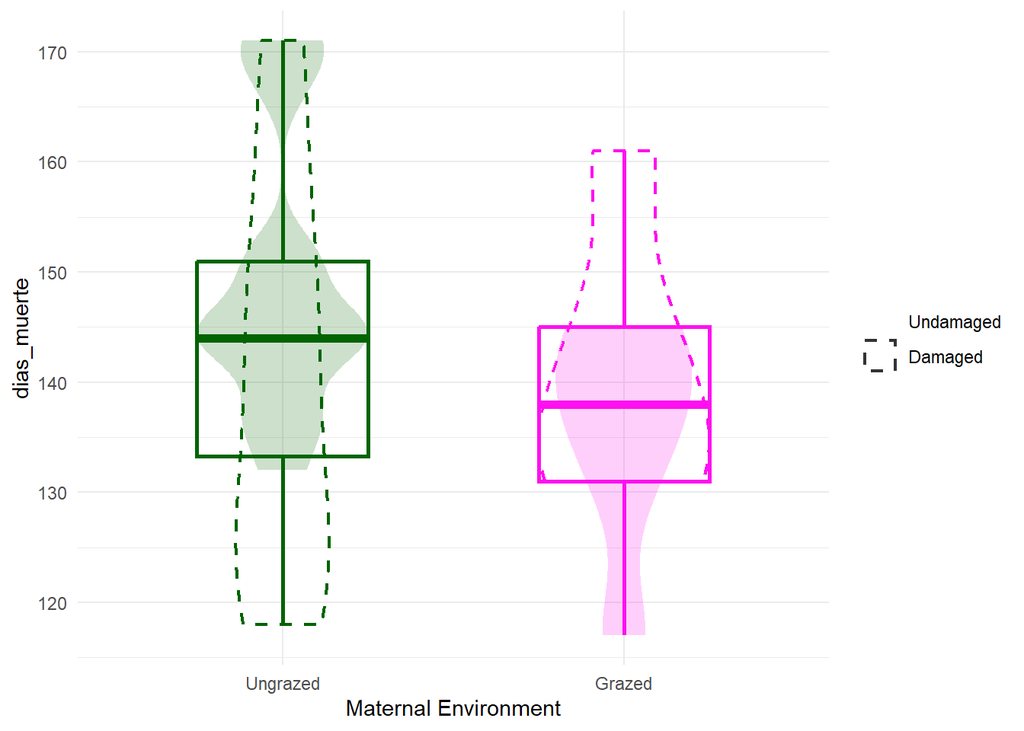

### C.arvensis - FENOLES

**sqrt(fenoles) ~ trat + clip + trat:clip**  
n = **31**

R² = **-0.0399432**

##### CAfenoles Post-hoc Comparisons with Tukeys HSD

| contrast | trat | estimate | SE | df | t.ratio | p.value |
| --- | --- | --- | --- | --- | --- | --- |
| no - yes | ex | -0.2842281 | 0.9872662 | 27 | -0.2878941 | 0.7756261 |
| no - yes | gra | -0.6561028 | 1.3367648 | 27 | -0.4908139 | 0.6275236 |

| contrast | clip | estimate | SE | df | t.ratio | p.value |
| --- | --- | --- | --- | --- | --- | --- |
| ex - gra | no | 1.1791104 | 1.139997 | 27 | 1.0343103 | 0.3101669 |
| ex - gra | yes | 0.8072358 | 1.209149 | 27 | 0.6676064 | 0.5100514 |

ANOVA Results for CAfenoles Model

| Response | Predictor | Sum Sq | Df | F value | Pr(>F) |
| --- | --- | --- | --- | --- | --- |
| CA fenoles | trat | 7.142 | 1 | 1.465 | 0.237 |
| CA fenoles | clip | 1.334 | 1 | 0.274 | 0.605 |
| CA fenoles | trat:clip | 0.244 | 1 | 0.050 | 0.825 |
| CA fenoles | Residuals | 131.584 | 27 | NA | NA |

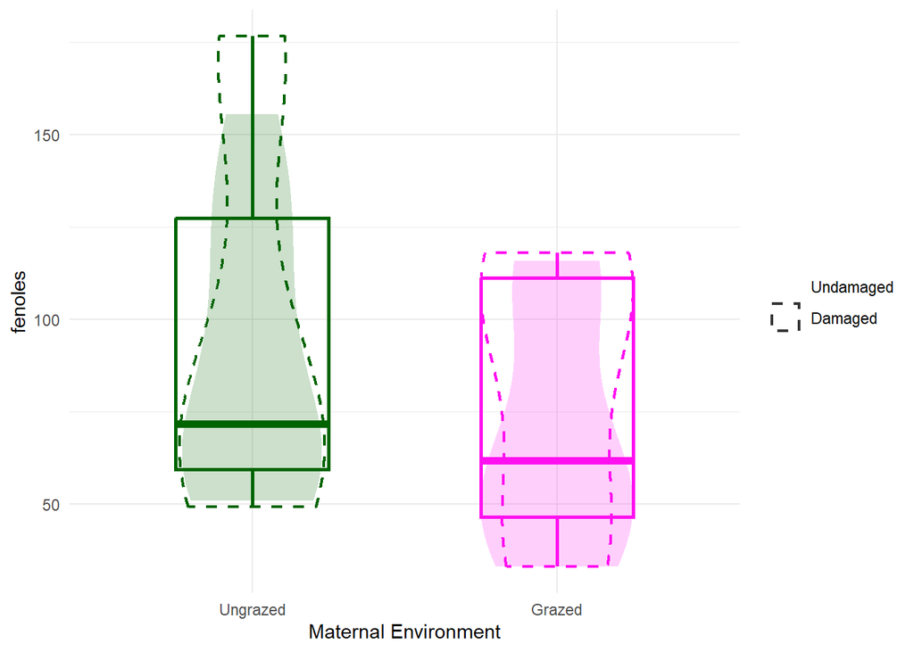